# Pitch Classification:

## *Using statcast and pitchfx data to classify pitch type*

This example will use all of Max Scherzer's pitches from the 2019 season.

By evaluating certain pitch characteristics we can classify each pitch in real time.

```python
# Load the data
scherzer_stats = pd.read_csv('https://raw.githubusercontent.com/jphil-16/Thinkful_Projects_JDP/main/scherzer_data.csv')

# Strip the data down to the relevant features
statcast_data = scherzer_stats[["pitch_type", "release_speed", "release_pos_x",	"release_pos_z", "release_extension", "release_spin_rate", "effective_speed", 'pfx_x', 'pfx_z']]

# Take a quick look
statcast_data.head()
```

|  | pitch_type | release_speed | release_pos_x | release_pos_z | release_extension | release_spin_rate | effective_speed | pfx_x | pfx_z |
| --- | --- | --- | --- | --- | --- | --- | --- | --- | --- |
| 0 | FF | 92.7 | -3.33 | 5.28 | 6.5 | 2299.0 | 93.1 | -0.94 | 1.21 |
| 1 | CH | 84.4 | -3.30 | 5.25 | 6.3 | 1494.0 | 84.3 | -1.34 | 0.09 |
| 2 | FF | 97.4 | -3.14 | 5.36 | 6.2 | 2465.0 | 97.2 | -0.84 | 1.35 |
| 3 | SL | 84.8 | -3.40 | 5.06 | 6.2 | 2295.0 | 84.5 | 0.46 | -0.02 |
| 4 | CU | 79.1 | -3.29 | 5.38 | 5.7 | 2818.0 | 78.4 | 0.80 | 0.03 |

### Evaluating the pitch types for Max Scherzer

Because this dataset already has labels, this is technically not unsupervised learning. However, these labels will allow us to better evaluate the model and determine whether it can be applied moving forward to new datasets without labels.

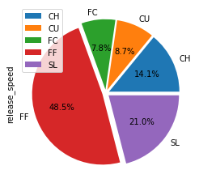

```python
# Look at a pie chart of the pitch type
grouped_data = statcast_data.groupby("pitch_type").agg('count')
grouped_data.plot.pie(y = "release_speed", autopct="%.1f%%", explode=[0.05]*5)
```

### Exploring the data

Pitch velocity is one of the primary differentiators between pitches

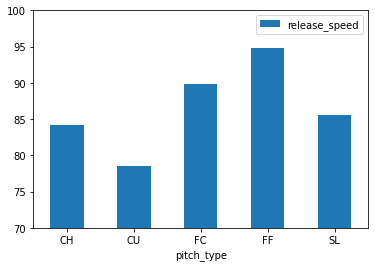

```python
# Take a look at pitch velocity
grouped_data = statcast_data.groupby("pitch_type").agg('mean')[["release_speed"]]
ax = grouped_data.plot.bar(rot=0, ylim = [70,100])
```

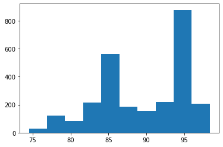

```python
# Make a histogram for all pitches
statcast_data.release_speed.hist(grid = False)
```

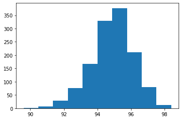

```python
# Make a histogram for only fastballs
fastball_df = statcast_data.loc[statcast_data['pitch_type'] == "FF"]
fastball_df.release_speed.hist(grid = False)
```

Spin rate is another key differentiator

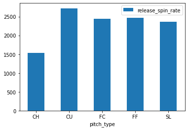

```python
# Take a look at spin rate
grouped_data = statcast_data.groupby("pitch_type").agg('mean')
grouped_data = grouped_data[["release_spin_rate"]]
ax = grouped_data.plot.bar(rot=0)
```

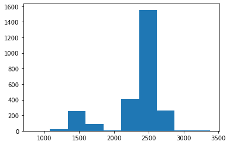

```python
# Make a histogram for all pitches
statcast_data.release_spin_rate.hist(grid = False)
```

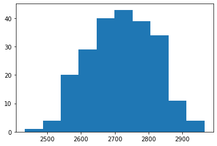

```python
# Make a histogram for only curveballs
curveball_df = statcast_data.loc[statcast_data['pitch_type'] == "CU"]
curveball_df.release_spin_rate.hist(grid = False)
```

### Cleaning the data

(And preparing for modeling)

```python
# Drop null values
statcast_data.dropna(inplace = True)

# Redefine the pitch type to be integers
for i in range(len(statcast_data)):
  if statcast_data.iloc[i, 0] == "FF": # 4-seam fastball
    statcast_data.iloc[i, 0] = 1
  elif statcast_data.iloc[i, 0] == "CH": # Changeup
    statcast_data.iloc[i, 0] = 2
  elif statcast_data.iloc[i, 0] == "SL": # Slider
    statcast_data.iloc[i, 0] = 3
  elif statcast_data.iloc[i, 0] == "CU": # Curveball
    statcast_data.iloc[i, 0] = 4
  elif statcast_data.iloc[i, 0] == "FC": # Cutter
    statcast_data.iloc[i, 0] = 5
```

```python
# Select data for clustering
X = statcast_data.iloc[:, np.r_[1:8,]]
y = statcast_data.iloc[:, 0]
y = y.to_numpy()
```

```python
# Standarizing the features
scaler = StandardScaler()
X_std = scaler.fit_transform(X)
```

### The fun begins!

We are going to look at 3 main clustering models: DBSCAN, K-means, and Agglomerative.

We will build and tune each clustering method in the order above.

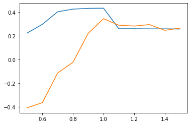

```python
# DBSCAN, epsilon
epsilon_test = [0.5, 0.6, 0.7, 0.8, 0.9, 1, 1.1, 1.2, 1.3, 1.4, 1.5]
ari_scores = []
silhouette_scores = []

for i in epsilon_test:
    dbscan_cluster = DBSCAN(eps=i, min_samples=3, metric="euclidean")
    clusters = dbscan_cluster.fit_predict(X_std)
    ari_scores.append(metrics.adjusted_rand_score(y, clusters))
    silhouette_scores.append(metrics.silhouette_score(X_std, clusters, metric='euclidean'))

plt.plot(epsilon_test, ari_scores,
        epsilon_test, silhouette_scores)
```

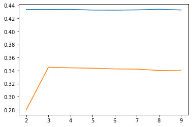

```python
# DBSCAN, min_samples
min_samples_test = range(2,10)
ari_scores = []
silhouette_scores = []

for i in min_samples_test:
    dbscan_cluster = DBSCAN(eps=1, min_samples=i, metric="euclidean")
    clusters = dbscan_cluster.fit_predict(X_std)
    ari_scores.append(metrics.adjusted_rand_score(y, clusters))
    silhouette_scores.append(metrics.silhouette_score(X_std, clusters, metric='euclidean'))

plt.plot(min_samples_test, ari_scores,
        min_samples_test, silhouette_scores)
```

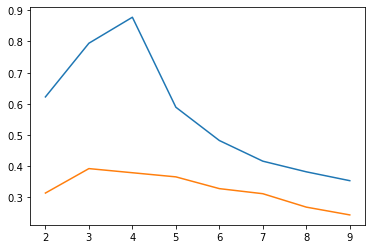

```python
# K-means
n_clusters_test = range(2,10)
ari_scores = []
silhouette_scores = []

for i in n_clusters_test:
    kmeans_cluster = KMeans(n_clusters=i, random_state=12)
    kmeans_cluster.fit(X_std)
    y_pred = kmeans_cluster.predict(X_std)
    ari_scores.append(metrics.adjusted_rand_score(y, y_pred))
    silhouette_scores.append(metrics.silhouette_score(X_std, y_pred, metric='euclidean'))

plt.plot(n_clusters_test, ari_scores,
        n_clusters_test, silhouette_scores)
```

```python
# Agglomerative

# Defining the agglomerative clustering - average
agg_cluster = AgglomerativeClustering(linkage="average", affinity='cosine', n_clusters=4)
# Get Results
clusters = agg_cluster.fit_predict(X_std)
print("ARI score of linkage method average: {}".format(metrics.adjusted_rand_score(y, clusters)))
print("Silhouette score of linkage method average: {}".format(metrics.silhouette_score(X_std, clusters, metric='euclidean')))
print("------------------------------------------------")


# Defining the agglomerative clustering - complete
agg_cluster = AgglomerativeClustering(linkage="complete", affinity='cosine', n_clusters=4)
# Get Results
clusters = agg_cluster.fit_predict(X_std)
print("ARI score of linkage method complete: {}".format(metrics.adjusted_rand_score(y, clusters)))
print("Silhouette score of linkage method complete: {}".format(metrics.silhouette_score(X_std, clusters, metric='euclidean')))
print("------------------------------------------------")


# Defining the agglomerative clustering - ward
agg_cluster = AgglomerativeClustering(linkage="ward", affinity='euclidean', n_clusters=4)
# Get Results
clusters = agg_cluster.fit_predict(X_std)
print("ARI score of linkage method ward: {}".format(metrics.adjusted_rand_score(y, clusters)))
print("Silhouette score of linkage method ward: {}".format(metrics.silhouette_score(X_std, clusters, metric='euclidean')))
print("------------------------------------------------")
```

```
ARI score of linkage method average: 0.8102022311276262
Silhouette score of linkage method average: 0.280924223064413
------------------------------------------------
ARI score of linkage method complete: 0.8243436127211193
Silhouette score of linkage method complete: 0.33470205723602536
------------------------------------------------
ARI score of linkage method ward: 0.9030471149546587
Silhouette score of linkage method ward: 0.37430455473319135
------------------------------------------------
```

### Results

With each method tuned and optimized, we can use ARI scores and Silhuoette scores to compare their performance

```python
# Agglomerative
agg_cluster = AgglomerativeClustering(linkage="ward", affinity='euclidean', n_clusters=4)
clusters = agg_cluster.fit_predict(X_std)
print("Agglomerative")
print("ARI score: {}".format(metrics.adjusted_rand_score(y, clusters)))
print("Silhouette score: {}".format(metrics.silhouette_score(X_std, clusters, metric='euclidean')))
print("------------------------------------------------")

# DBSCAN
dbscan_cluster = DBSCAN(eps=1, min_samples=3, metric="euclidean")
clusters = dbscan_cluster.fit_predict(X_std)
print("DBSCAN")
print("ARI score: {}".format(metrics.adjusted_rand_score(y, clusters)))
print("Silhouette score: {}".format(metrics.silhouette_score(X_std, clusters, metric='euclidean')))
print("------------------------------------------------")

# K-Means
kmeans_cluster = KMeans(n_clusters=4, random_state=12)
kmeans_cluster.fit(X_std)
y_pred = kmeans_cluster.predict(X_std)
print("K-Means")
print("ARI score of Kmeans: {}".format(metrics.adjusted_rand_score(y, y_pred)))
print("Silhouette score of Kmeans: {}".format(metrics.silhouette_score(X_std, y_pred, metric='euclidean')))
```

```
Agglomerative
ARI score: 0.9030471149546587
Silhouette score: 0.37430455473319135
------------------------------------------------
DBSCAN
ARI score: 0.43356654718507753
Silhouette score: 0.3451063718959263
------------------------------------------------
K-Means
ARI score of Kmeans: 0.8775618993894281
Silhouette score of Kmeans: 0.37917131841889323
```

Each of the three methods performed similarly when judged by Silhuoette score, but the Agglomerative and K-means methods performed much better when judged by ARI score. In this analysis, the Agglomerative method (with linkage method Ward) got the edge in performance with an ARI score of 0.90 and a Silhuoette score of 0.37.

### Dimensionality Reduction

Finally, we will look at 2 methods of dimensionality reduction and visualization: PCA and UMAP

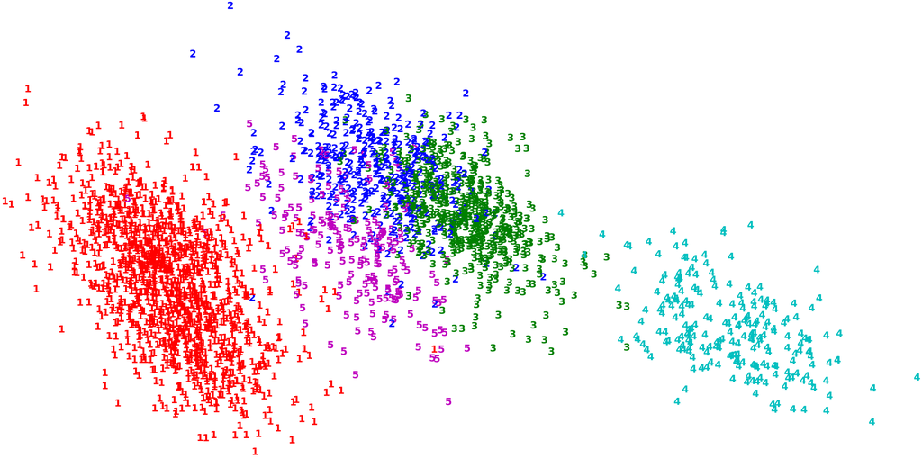

```python
pca = PCA(n_components=5).fit_transform(X_std)

plt.figure(figsize=(10,5))
colours = 'rbgcmykr'
for i in range(pca.shape[0]):
    plt.text(pca[i, 0], pca[i, 1], y[i],
             color=colours[int(y[i])-1],
             fontdict={'weight': 'bold', 'size': 50}
        )

plt.xticks([])
plt.yticks([])
plt.axis('off')
plt.show()
```

```python
# UMAP
umap_results = umap.UMAP(n_neighbors=3,
                      min_dist=0.3,
                      metric='correlation').fit_transform(X_std)

plt.figure(figsize=(10,5))
colours = ["r","b","g","c","m"]
for i in range(umap_results.shape[0]):
    plt.text(umap_results[i, 0], umap_results[i, 1], y[i],
             color=colours[int(y[i])-1],
             fontdict={'weight': 'bold', 'size': 50}
        )

plt.xticks([])
plt.yticks([])
plt.axis('off')
plt.show()
```

[figure not shown]

# Final thoughts

- Both Agglomerative Clustering and K-means Clustering performed fairly well
- Both PCA and UMAP showed some good seperation between the clusters, with cluster number 1 (fastballs) being very distinct in both visualizations
- Even though the true number of clusters was 5, the clustering methods were optimized with k=4
  - Based on the visualizations, it was hard to distinguish between the clusters for cutters and sliders (clusters 3 and 5)
  - This could be a key takeaway for Max Scherzer as he analyzes his repertoire: these pitches act very similarly and he may be best suited focusing on one and retiring the other, reducing his number of pitch types to 4
- Next steps: Apply this model to other pitchers to continue tuning the details before deploying it for the 2022 baseball season to classify pitches in real time and provide insights after the games.